# RNAseq 2

Ryota Chijimatsu

2023年5月

# pathway enrichment解析

得られたDEGの機能を探索するためpathway enrichment analysisを行います。  
ここで言うpathwayとは各データベースで定義されている遺伝子セットのことで、代表的なものに`Gene Ontology`, `KEGG`, `Reactome`, `Wikipathway`などがあります。  
それぞれのデータベースからpathwayごとの遺伝子セットを確認することができますが、[Molecular Signature Database](https://www.gsea-msigdb.org/gsea/msigdb/)からも確認することができます。

ここではclusterProfilerパッケージを使用した解析を紹介します。[vignette](https://yulab-smu.top/biomedical-knowledge-mining-book/index.html)

enrichment解析には大きく分けて2通りの手法があります。clusterProfilerではどちらの手法も行うことができます。

- 閾値以上のDEGのみを使用する方法 例えば、あるpathwayに登録されている遺伝子が10個あり、DEG 100個のうちに5個含まれていたとする。10個/全遺伝子と5個/DEGの割合を考えるとpathwayの遺伝子がDEGにエンリッチメントしていることが想定される。
- 発現変動差やp値のランキング順に並べた全遺伝子を使用する方法 全遺伝子をランキング順に並び替えた時に、あるpathwayの遺伝子がランキング上位にある程そのpathwayがエンリッチしていると考えることができる。

https://bi.biopapyrus.jp/pathway/go/

# ライブラリの用意

```r
# BiocManager::install("clusterProfiler")
library(clusterProfiler)
```

# 1. 発現変動遺伝子のエンリッチメント解析

## 1-2. DEGの用意

まずは閾値を満たす遺伝子を発現変動遺伝子として抽出し、それら遺伝子集団にエンリッチしている機能を探索します。

```r
DEGs <- read.csv(file = "edgeR_DGE.csv")
```

```r
dim(DEGs)
```

```
## [1] 10542     6
```

```r
head(DEGs)
```

|  | idRefSeq | nameOfGene | logFC | logCPM | PValue | FDR |
| --- | --- | --- | --- | --- | --- | --- |
| 1 | NM_004320 | ATP2A1 | -4.480940 | 5.469060 | 8.935100e-16 | 7.483949e-12 |
| 2 | NM_031469 | SH3BGRL2 | -4.032080 | 5.040447 | 1.419835e-15 | 7.483949e-12 |
| 3 | NM_005609 | PYGM | -5.250392 | 5.491972 | 2.260963e-15 | 7.945023e-12 |
| 4 | NM_002820 | PTHLH | 4.001370 | 5.711116 | 5.324984e-15 | 1.403399e-11 |
| 5 | NM_015278 | SASH1 | -3.325319 | 6.230338 | 1.112636e-13 | 2.345883e-10 |
| 6 | NM_001039585 | PTGFR | -5.128840 | 4.244825 | 3.451721e-13 | 6.064673e-10 |

上記は全遺伝子の情報を含んだままの状態です。閾値を満たす遺伝子を抽出します。

この例は正常検体に対して腫瘍検体で何倍差があるかという比較をしました。腫瘍検体で発現が上昇している機能を調べるためにはlogFCが1以上のものを抽出します。逆に正常組織で発現が高いものを抽出するにはlogFCが-1以下ものを選択すればよいです。

```r
up <- DEGs[ DEGs$logFC >= 1 & DEGs$FDR <= 0.05, "nameOfGene"]
length(up)
```

```
## [1] 220
```

DEG数が多すぎる場合はエンリッチメント解析の精度が悪くなることがあります。閾値を厳しくして遺伝子数を減らした場合でも同様の解析を流してみるとよいでしょう。

## 1-3. 遺伝子IDの変換

clusterProfilerでは**Entrez ID**を使用するため、遺伝子名で取得したDEGをEntrez IDへ変換する必要があります。

clusterProfilerの`bitr`機能でIDの変換が可能ですが、遺伝子アノテーションのためのパッケージを別途必要とします。

org.Hs.eg.dbはヒトの遺伝子アノテーション情報を含んだパッケージです。これまでのように機能を備えたパッケージではなくデータが登録されているものです。

```r
# BiocManager::install("org.Hs.eg.db")
library(org.Hs.eg.db)

# マウスの場合
# library(org.Mm.eg.db)
```

`bitr`機能で遺伝子名をEntrez IDに変換します。

```r
geneID <- bitr(geneID = up, # 変換する遺伝子ベクトル
               fromType = "SYMBOL", # 変換元は遺伝子名なのでSYMBOLを指定
               toType = "ENTREZID" , # 変換先にENTREZIDを指定
               OrgDb = org.Hs.eg.db # アノテーションパッケージを指定
               )
```

`bitr`ではデフォルトで`drop=TRUE`になっており、変換できなかったものは出力から除かれています。

```r
dim(geneID)
```

```
## [1] 204   2
```

```r
head(geneID)
```

|  | SYMBOL | ENTREZID |
| --- | --- | --- |
| 1 | PTHLH | 5744 |
| 2 | RBP1 | 5947 |
| 3 | TREM2 | 54209 |
| 4 | CALML5 | 51806 |
| 5 | COL4A6 | 1288 |
| 6 | SLC7A8 | 23428 |

出力は変換前の遺伝子名と変換後のENTREZ IDの2列から成るデータフレームです。ENTREZ IDしか使用しませんので抜き出しておきます。

```r
up <- geneID$ENTREZID
head(up)
```

```
## [1] "5744"  "5947"  "54209" "51806" "1288"  "23428"
```

## 1-4.エンリッチメント解析の実行

各pathwayデータベースごとに機能が用意されています。

### Gene ontology

`enrichGO`機能を使用します。Gene ontologyにはBiological process, Molecular function, cellular compornentの3つのカテゴリがあります。すべてを同時に解析することもできますが、それぞれやった方がよいでしょう。

```r
# Biological process
GOBP <- enrichGO(gene= up,
                 OrgDb = org.Hs.eg.db,
                 ont = "BP", # BP/MF/CC/ALLのうちどれか
                 readable = TRUE # ENTREZ IDを遺伝子名に変換するオプション
                 )
head(GOBP)
```

|  | ID | Description | GeneRatio | BgRatio | pvalue | p.adjust | qvalue | geneID | Count |
| --- | --- | --- | --- | --- | --- | --- | --- | --- | --- |
| GO:0043588 | GO:0043588 | skin development | 17/192 | 302/18903 | 1.318627e-08 | 4.340919e-05 | 3.682439e-05 | AKR1C3/WNT10A/MET/ABCA12/CDSN/ETV4/ITGB4/POU3F1/GLI2/CYP26B1/FZD6/ITGA6/INHBA/SOX9/CLDN1/ITGA2/KRT17 | 17 |
| GO:0008544 | GO:0008544 | epidermis development | 17/192 | 362/18903 | 1.824906e-07 | 3.003795e-04 | 2.548145e-04 | PTHLH/CALML5/LAMC2/AKR1C3/WNT10A/KLF7/LAMA3/ABCA12/CDSN/ETV4/POU3F1/GLI2/CYP26B1/FZD6/INHBA/SOX9/KRT17 | 17 |
| GO:0044089 | GO:0044089 | positive regulation of cellular component biogenesis | 18/192 | 498/18903 | 3.466743e-06 | 3.169861e-03 | 2.689020e-03 | PLEK2/HAP1/MET/FSCN1/TPBG/AGRN/SDC4/IRX3/PHLDB2/MTSS1/PYCARD/SOX9/PIP4K2C/TFRC/BID/BAIAP2L2/CLDN1/HAS3 | 18 |
| GO:0043589 | GO:0043589 | skin morphogenesis | 4/192 | 12/18903 | 4.791138e-06 | 3.169861e-03 | 2.689020e-03 | CDSN/ITGB4/ITGA6/ITGA2 | 4 |
| GO:0007411 | GO:0007411 | axon guidance | 12/192 | 236/18903 | 5.533400e-06 | 3.169861e-03 | 2.689020e-03 | LAMC2/EFNB1/KLF7/LAMA3/EFNA1/GLI2/EPHB4/SEMA3C/PLXNB3/PLXNA1/EFNB2/SIAH1 | 12 |
| GO:0097485 | GO:0097485 | neuron projection guidance | 12/192 | 237/18903 | 5.777390e-06 | 3.169861e-03 | 2.689020e-03 | LAMC2/EFNB1/KLF7/LAMA3/EFNA1/GLI2/EPHB4/SEMA3C/PLXNB3/PLXNA1/EFNB2/SIAH1 | 12 |

MFとCCもやっておきます。

```r
GOMF <- enrichGO(gene= up, OrgDb = org.Hs.eg.db, ont = "MF",readable = TRUE)
GOCC <- enrichGO(gene= up, OrgDb = org.Hs.eg.db, ont = "CC",readable = TRUE)
```

### KEGG

`enrichKEGG`機能を使用します。enrichGOと異なり、`organism`引数に生物種を指定します。指定する際の名前はKEGGで管理されている生物名が必要です。https://www.genome.jp/kegg/catalog/org_list.html

`readable`オプションはありません。

```r
kegg <- enrichKEGG(gene = up,
                   organism = "hsa", # マウスならmmu
                   )
```

```
## Reading KEGG annotation online: "https://rest.kegg.jp/link/hsa/pathway"...
```

```
## Reading KEGG annotation online: "https://rest.kegg.jp/list/pathway/hsa"...
```

```r
head(kegg)
```

|  | ID | Description | GeneRatio | BgRatio | pvalue | p.adjust | qvalue | geneID | Count |
| --- | --- | --- | --- | --- | --- | --- | --- | --- | --- |
| hsa04512 | hsa04512 | ECM-receptor interaction | 11/113 | 89/8467 | 2.233002e-08 | 4.577655e-06 | 4.066415e-06 | 1288/3918/6696/1287/3909/3696/375790/6385/3691/3655/3673 | 11 |
| hsa05165 | hsa05165 | Human papillomavirus infection | 18/113 | 331/8467 | 3.276856e-07 | 3.358777e-05 | 2.983663e-05 | 1288/3918/7477/6696/8638/80326/1287/3909/3696/1021/7483/54626/898/3691/8323/3655/7482/3673 | 18 |
| hsa04510 | hsa04510 | Focal adhesion | 12/113 | 203/8467 | 1.540388e-05 | 8.712857e-04 | 7.739791e-04 | 1288/3918/6696/1287/4233/3909/3696/858/3691/7410/3655/3673 | 12 |
| hsa05205 | hsa05205 | Proteoglycans in cancer | 12/113 | 205/8467 | 1.700070e-05 | 8.712857e-04 | 7.739791e-04 | 7477/3236/80326/4233/858/6385/7483/3710/7410/8323/7482/3673 | 12 |
| hsa05222 | hsa05222 | Small cell lung cancer | 8/113 | 92/8467 | 2.877206e-05 | 1.179654e-03 | 1.047909e-03 | 1288/3918/1287/3909/1021/898/3655/3673 | 8 |
| hsa05217 | hsa05217 | Basal cell carcinoma | 6/113 | 63/8467 | 1.809876e-04 | 6.183744e-03 | 5.493133e-03 | 7477/80326/7483/2736/8323/7482 | 6 |

enrichKEGGの中でENTREZ IDを遺伝子名に変換するオプションはありませんが、`setReadable`機能で変換することができます。

```r
kegg <- setReadable(kegg, OrgDb = org.Hs.eg.db, keyType = "ENTREZID")
```

### Wikipathway

`enrichWP`機能を使用します。`organism`引数で生物種を指定しますが、KEGGとは指定する名前が異なりますので注意してください。

`get_wp_organisms()`で指定可能な生物種一覧が確認できます。

```r
get_wp_organisms()
```

```
##  [1] "Sus scrofa"               "Solanum lycopersicum"
##  [3] "Saccharomyces cerevisiae" "Rattus norvegicus"
##  [5] "Populus trichocarpa"      "Pan troglodytes"
##  [7] "Mus musculus"             "Homo sapiens"
##  [9] "Gallus gallus"            "Equus caballus"
## [11] "Drosophila melanogaster"  "Danio rerio"
## [13] "Canis familiaris"         "Caenorhabditis elegans"
## [15] "Bos taurus"               "Arabidopsis thaliana"
```

`readable`オプションはありませんので、`setReadable`機能を使用します。

```r
wiki <- enrichWP(gene = up,
                 organism = "Homo sapiens")
wiki <- setReadable(wiki, OrgDb = org.Hs.eg.db, keyType = "ENTREZID")
head(wiki)
```

|  | ID | Description | GeneRatio | BgRatio | pvalue | p.adjust | qvalue | geneID | Count |
| --- | --- | --- | --- | --- | --- | --- | --- | --- | --- |
| WP4658 | WP4658 | Small cell lung cancer | 9/126 | 96/8444 | 1.196773e-05 | 0.003386868 | 0.002960439 | COL4A6/LAMC2/COL4A5/LAMA3/CDK6/CCNE1/ITGA6/BID/ITGA2 | 9 |
| WP306 | WP306 | Focal adhesion | 12/126 | 198/8444 | 3.712666e-05 | 0.005253423 | 0.004591982 | COL4A6/LAMC2/SPP1/TNK1/MET/LAMA3/ITGB8/CAV2/ITGB4/VAV2/ITGA6/ITGA2 | 12 |
| WP5087 | WP5087 | Malignant pleural mesothelioma | 18/126 | 440/8444 | 8.564522e-05 | 0.008079199 | 0.007061974 | COL4A6/LAMC2/WNT7B/WNT10A/SLC2A1/COL4A5/FOXM1/MET/LAMA3/EFNA1/SLC3A2/CCNE1/ITPR3/ITGB4/FZD6/ITGA6/WNT2B/ITGA2 | 18 |
| WP3932 | WP3932 | Focal adhesion: PI3K-Akt-mTOR-signaling pathway | 14/126 | 302/8444 | 1.544390e-04 | 0.010926558 | 0.009550832 | COL4A6/LAMC2/SPP1/SLC2A1/COL11A1/MET/LAMA3/ITGB8/EFNA1/PFKFB4/ITGB4/ITGA6/DDIT4/ITGA2 | 14 |
| WP3872 | WP3872 | Regulation of apoptosis by parathyroid hormone-related protein | 4/126 | 23/8444 | 3.359538e-04 | 0.015928390 | 0.013922900 | PTHLH/ITGB4/ITGA6/BID | 4 |
| WP4787 | WP4787 | Osteoblast differentiation and related diseases | 8/126 | 119/8444 | 3.864139e-04 | 0.015928390 | 0.013922900 | WNT7B/WNT10A/WNT9A/HES2/GLI2/FZD6/WNT2B/SOX9 | 8 |

### Reactome

Reactomeデータベースのpathwayを使うには`ReactomePA`パッケージが必要となります。

```r
# BiocManager::install("ReactomePA")
library(ReactomePA)
```

`enrichPathway`機能を使用します。`organism`引数は次のどれか指定します。 “human”, “rat”, “mouse”, “celegans”, “yeast”, “zebrafish”, “fly”

`readable``引数が使えます。

```r
reactome <- enrichPathway(gene = up,
                          organism = "human",
                          readable = TRUE
                          )
head(reactome)
```

|  | ID | Description | GeneRatio | BgRatio | pvalue | p.adjust | qvalue | geneID | Count |
| --- | --- | --- | --- | --- | --- | --- | --- | --- | --- |
| R-HSA-3000171 | R-HSA-3000171 | Non-integrin membrane-ECM interactions | 12/145 | 59/10899 | 1.272726e-11 | 6.872722e-09 | 6.162675e-09 | COL4A6/LAMC2/CASK/COL4A5/COL11A1/LAMA3/AGRN/SDC4/ITGB4/COL10A1/ITGA6/ITGA2 | 12 |
| R-HSA-1474244 | R-HSA-1474244 | Extracellular matrix organization | 18/145 | 300/10899 | 8.788036e-08 | 1.809765e-05 | 1.622791e-05 | COL4A6/LAMC2/SPP1/MMP11/CASK/COL4A5/MMP12/COL11A1/LAMA3/ITGB8/AGRN/SDC4/ITGB4/COL10A1/ITGA6/SERPINE1/CAPN12/ITGA2 | 18 |
| R-HSA-3000157 | R-HSA-3000157 | Laminin interactions | 7/145 | 30/10899 | 1.005425e-07 | 1.809765e-05 | 1.622791e-05 | COL4A6/LAMC2/COL4A5/LAMA3/ITGB4/ITGA6/ITGA2 | 7 |
| R-HSA-2022090 | R-HSA-2022090 | Assembly of collagen fibrils and other multimeric structures | 8/145 | 61/10899 | 1.313081e-06 | 1.772659e-04 | 1.589519e-04 | COL4A6/LAMC2/COL4A5/COL11A1/LAMA3/ITGB4/COL10A1/ITGA6 | 8 |
| R-HSA-446107 | R-HSA-446107 | Type I hemidesmosome assembly | 4/145 | 11/10899 | 9.224798e-06 | 9.962781e-04 | 8.933488e-04 | LAMC2/LAMA3/ITGB4/ITGA6 | 4 |
| R-HSA-216083 | R-HSA-216083 | Integrin cell surface interactions | 8/145 | 85/10899 | 1.640293e-05 | 1.289996e-03 | 1.156722e-03 | COL4A6/SPP1/COL4A5/ITGB8/AGRN/COL10A1/ITGA6/ITGA2 | 8 |

### Disease Ontology

`DOSE`パッケージが別途必要になります。

```r
# BiocManager::install("DOSE")
library(DOSE)
```

``enrichDO`機能を使用します。`readable`オプションも使えます。

```r
dose <- enrichDO(gene = up, readable = TRUE)
head(dose)
```

|  | ID | Description | GeneRatio | BgRatio | pvalue | p.adjust | qvalue | geneID | Count |
| --- | --- | --- | --- | --- | --- | --- | --- | --- | --- |
| DOID:0060084 | DOID:0060084 | cell type benign neoplasm | 19/140 | 480/10312 | 2.496266e-05 | 0.008570037 | 0.007572449 | PTHLH/RBP1/COL4A6/SLC2A1/COL4A5/COL11A1/PLAG1/MET/FSCN1/HMGA2/DNMT3B/SLC3A2/FZD6/ODC1/CSPG4/SOX9/CLDN1/ITGA2/HMGA1 | 19 |
| DOID:5520 | DOID:5520 | head and neck squamous cell carcinoma | 12/140 | 208/10312 | 2.502200e-05 | 0.008570037 | 0.007572449 | AKR1C3/MET/CAV2/DNMT3B/SLC7A11/SLC3A2/CCNE1/VAV2/EPHB4/SERPINE1/CSPG4/DDIT4 | 12 |
| DOID:10534 | DOID:10534 | stomach cancer | 17/140 | 416/10312 | 4.646801e-05 | 0.010610195 | 0.009375124 | SPP1/MMP11/SLC2A1/FOXM1/MET/HSD17B2/EFNA1/DNMT3B/HLTF/ITPR3/SERPINE1/WNT2B/PLXNA1/BID/SIAH1/ITGA2/KRT17 | 17 |
| DOID:1542 | DOID:1542 | head and neck carcinoma | 13/140 | 269/10312 | 7.253740e-05 | 0.012422030 | 0.010976054 | AKR1C3/SLC2A1/MET/CAV2/DNMT3B/SLC7A11/SLC3A2/CCNE1/VAV2/EPHB4/SERPINE1/CSPG4/DDIT4 | 13 |
| DOID:11934 | DOID:11934 | head and neck cancer | 13/140 | 276/10312 | 9.413179e-05 | 0.012896055 | 0.011394900 | AKR1C3/SLC2A1/MET/CAV2/DNMT3B/SLC7A11/SLC3A2/CCNE1/VAV2/EPHB4/SERPINE1/CSPG4/DDIT4 | 13 |
| DOID:3910 | DOID:3910 | lung adenocarcinoma | 12/140 | 263/10312 | 2.370940e-04 | 0.019020134 | 0.016806111 | PTHLH/MET/LAMA3/CDK6/DNMT3B/SLC3A2/CCNE1/ITGB4/COL10A1/INHBA/SOX9/BID | 12 |

## 1-5. 結果の可視化

clusterProfilerパッケージは解析結果のオブジェクトを使った描画機能も提供しています。 https://yulab-smu.top/biomedical-knowledge-mining-book/enrichplot.html

一部のplotには`enrichplot`パッケージが必要になるので入れておきましょう。

```r
# BiocManager::install("enrichplot")
library(enrichplot)
```

### dotplot

`dotplot`機能で有意なpathwayを可視化します。

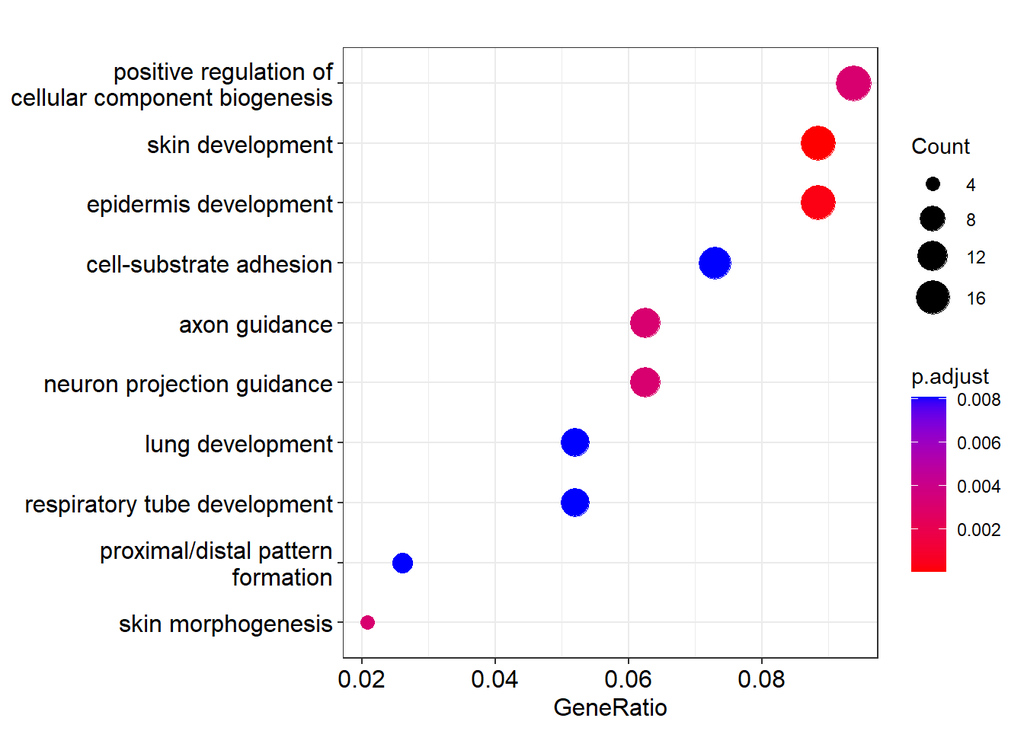

```r
dotplot(object = GOBP)
```

上皮系の発生などのtermが目立っています。

`showCategory`引数で上位いくつのpathwayを表示するか指定できます。

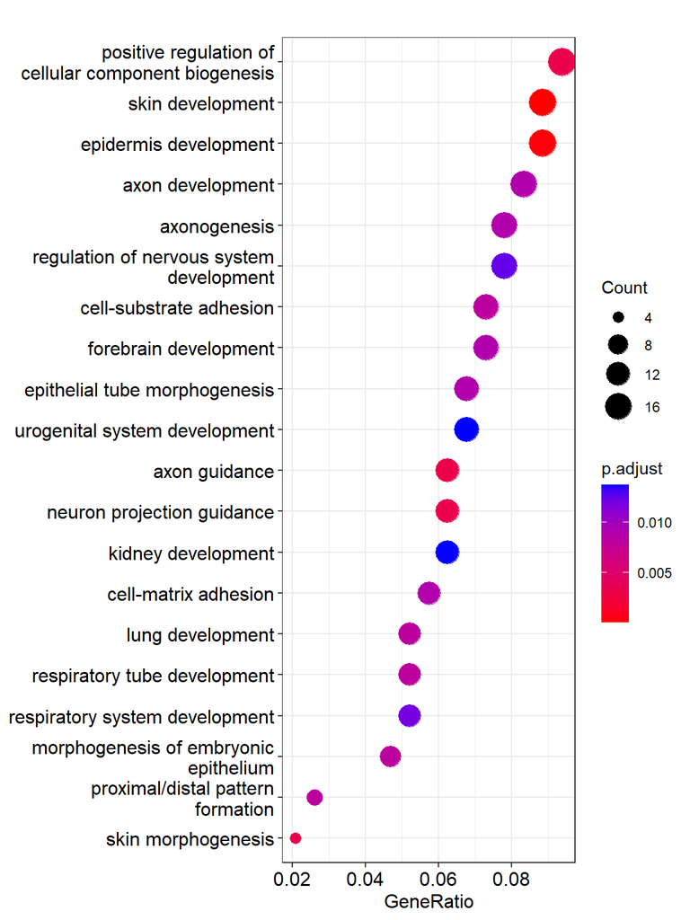

```r
dotplot(object = GOBP, showCategory = 20)
```

`showCategory`引数にpathwayの名前を入れて特定のpathwayだけを表示させることもできます。

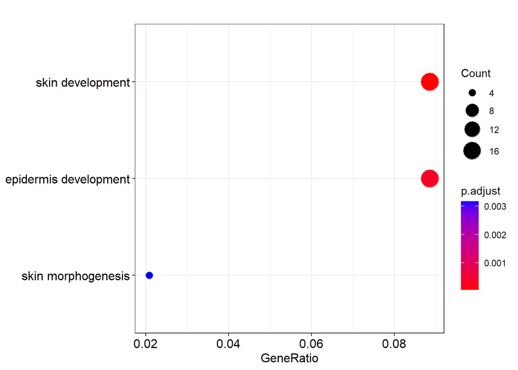

```r
dotplot(object = GOBP, showCategory = c("skin development", "skin morphogenesis", "epidermis development"))
```

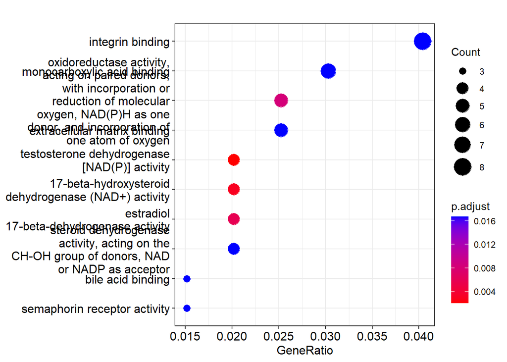

```r
dotplot(GOMF)
```

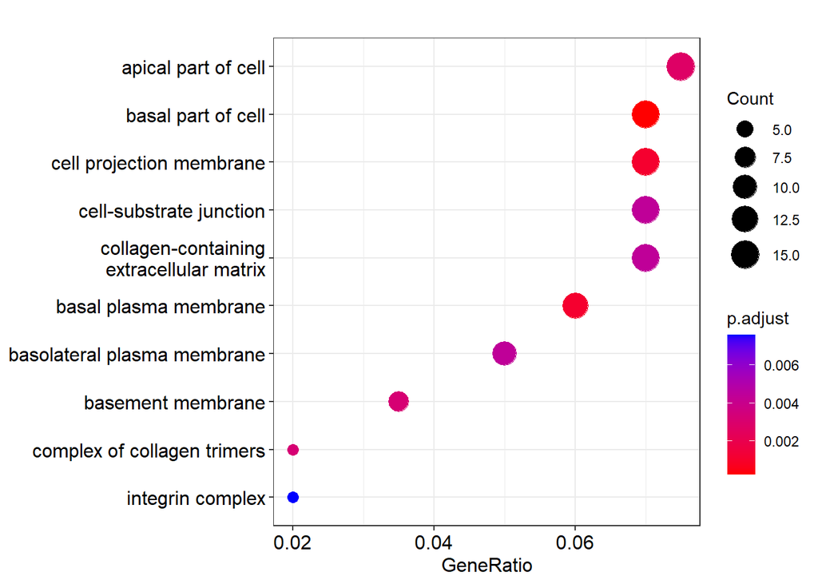

```r
dotplot(GOCC)
```

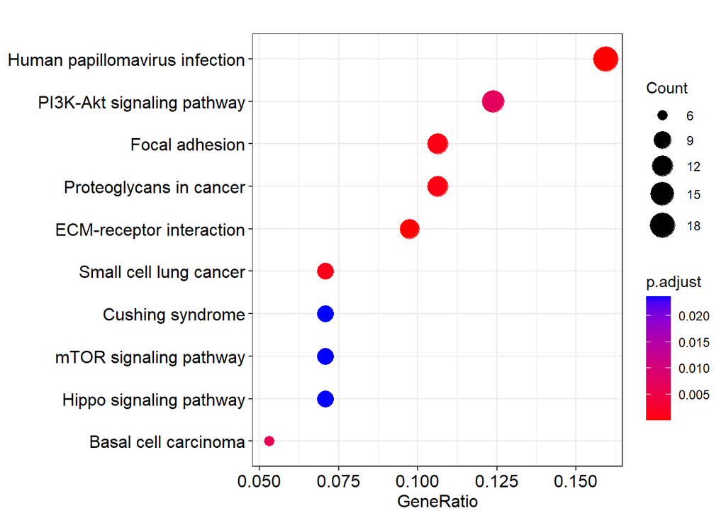

```r
dotplot(kegg)
```

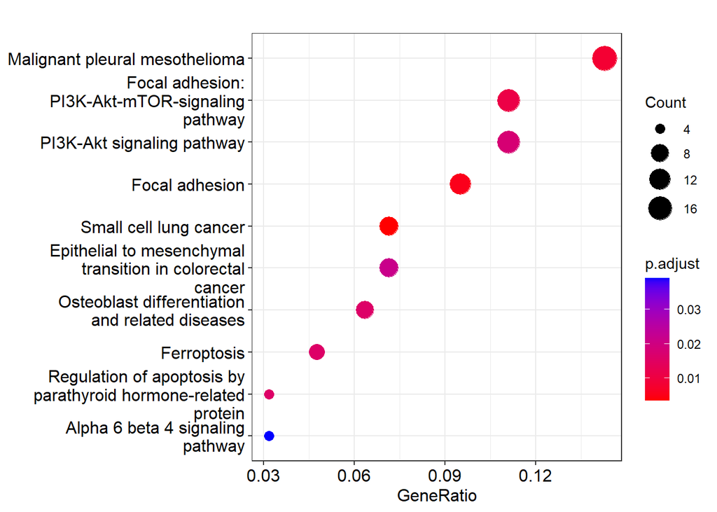

```r
dotplot(wiki)
```

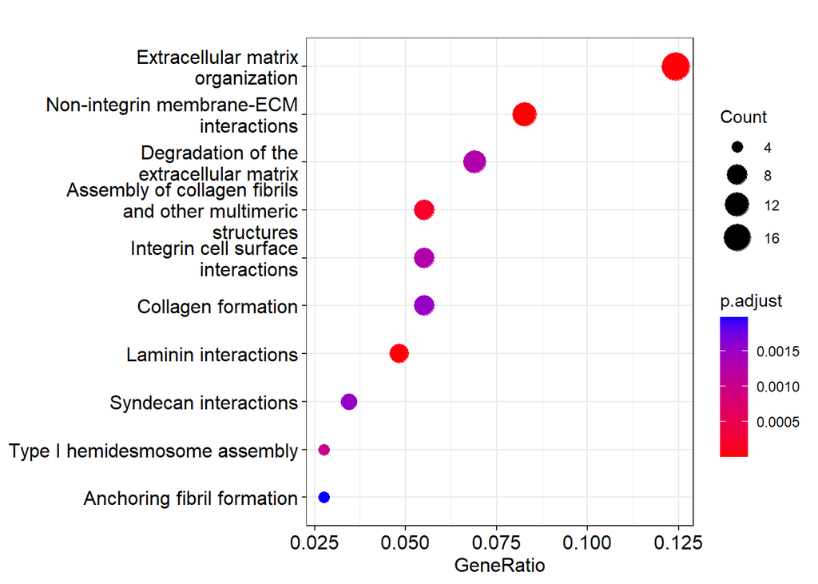

```r
dotplot(reactome)
```

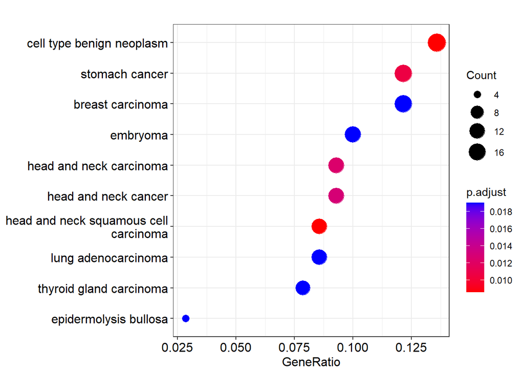

```r
dotplot(dose)
```

clusterProfilerの描画はggplot2を内部で使用しているため、ggplot2による修飾コマンドが使用できます。  
上記のGOMFはplotするとpathway名が長くて一部重なっていましたが、以下のように編集することができます。

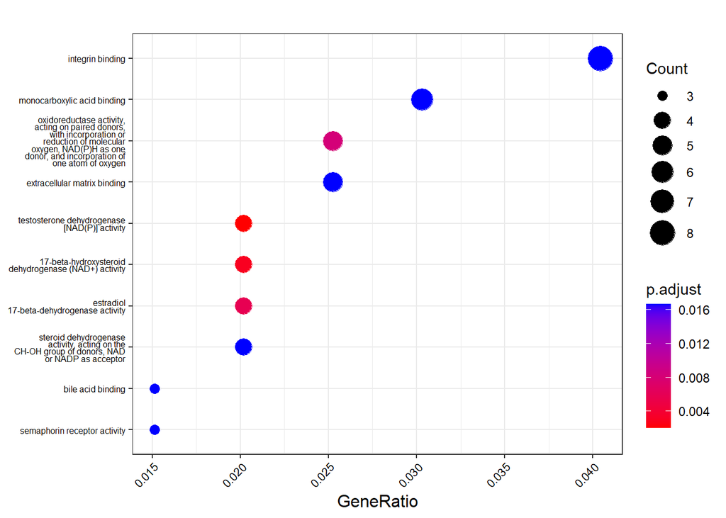

```r
library(ggplot2)

dotplot(GOMF)  +
  theme(axis.text.y = element_text(size = 6, lineheight = 0.7),
        axis.text.x = element_text(angle = 45, hjust = 1, size = 8))
```

### Gene-Concept Network

各pathwayは完全にユニークな遺伝子で構成されているわけではなく、1つの遺伝子は複数のpathwayに登録されています。  
`cnetplot`機能では有意なpathway間の繋がりを可視化することができます。

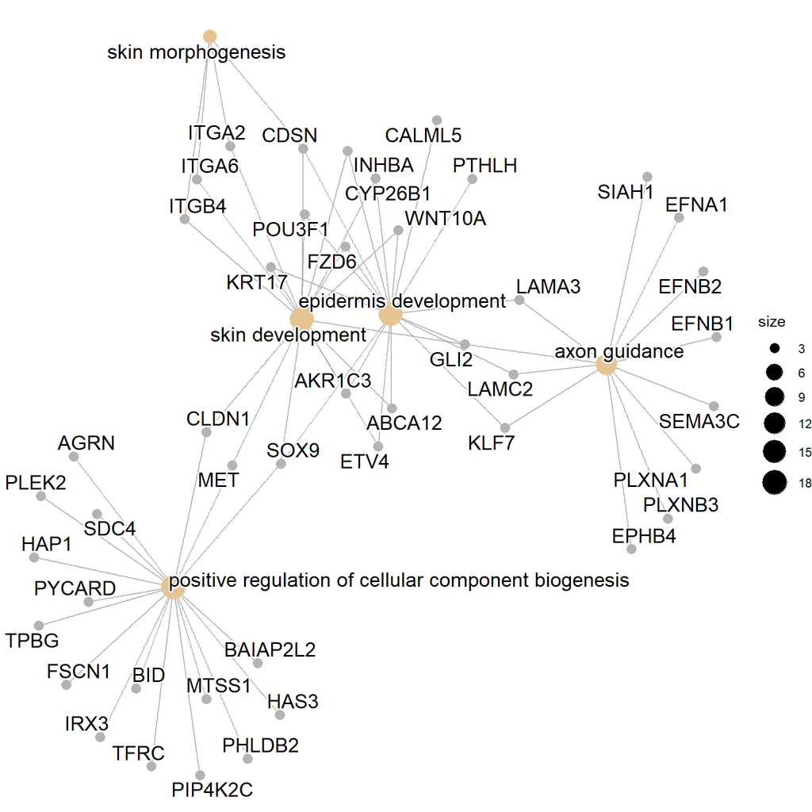

```r
cnetplot(GOBP)
```

以下のようにplotの調整が可能です。

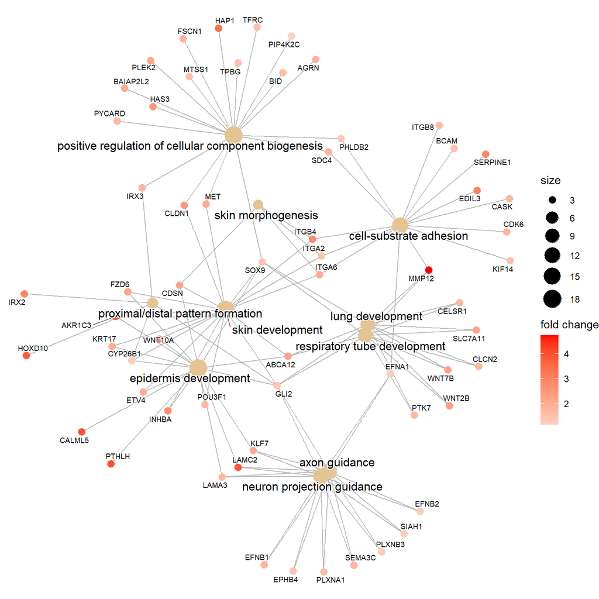

```r
# logFCのベクトルの名前属性に遺伝子名を入れる
foldChange <- DEGs$logFC
names(foldChange) <- DEGs$nameOfGene

cnetplot(GOBP,
         foldChange = foldChange,
         showCategory = 10,
         cex_label_gene = 0.5, # 遺伝子のラベルサイズ
         cex_label_category = 0.8 # pathwayのラベルサイズ
         )
```

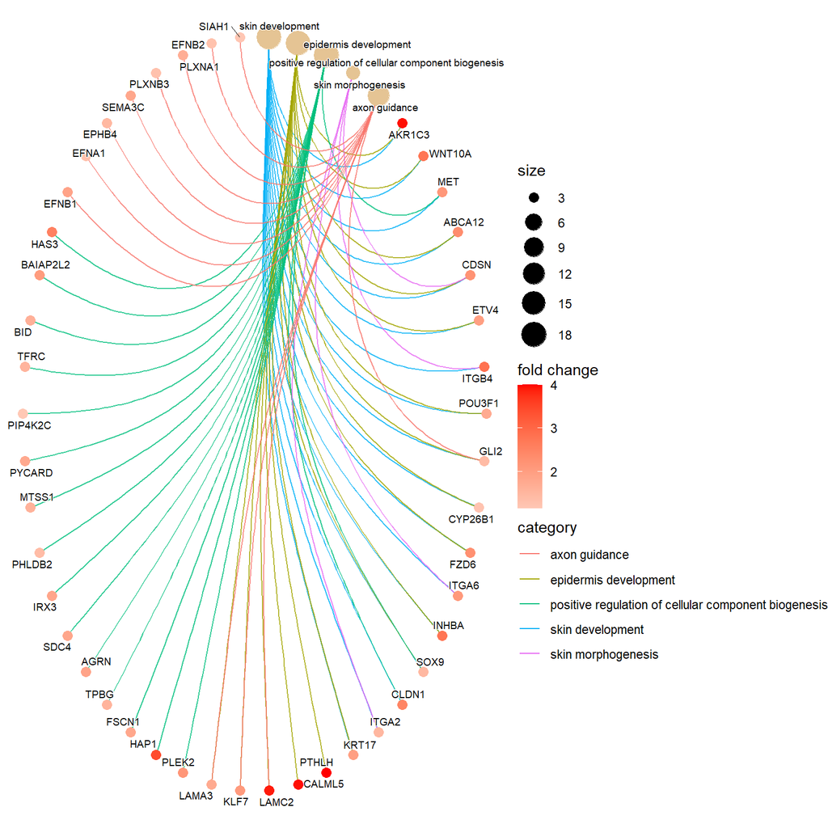

```r
cnetplot(GOBP,
         foldChange = foldChange,
         showCategory = 5,
         cex_label_gene = 0.5, # 遺伝子のラベルサイズ
         cex_label_category = 0.5, # pathwayのラベルサイズ
         circular = TRUE, # 環状に配置
         colorEdge = TRUE, # edgeに色を付ける
         )
```

### Heatplot

各pathwayとヒットしたDEGの関係を表現できます。

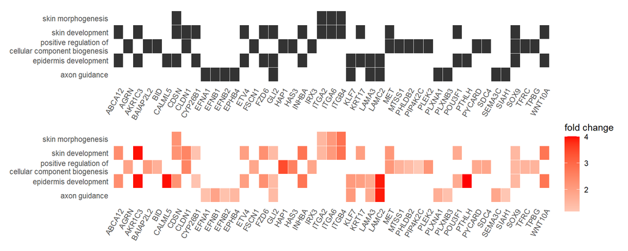

```r
library(patchwork)
p1 <- heatplot(GOBP, showCategory=5)
p2 <- heatplot(GOBP, foldChange=foldChange, showCategory=5)
p1/p2
```

# 2. 遺伝子ランキングに基づくエンリッチメント解析

上記の手法では閾値次第で結果が変わることや、発現変動量の情報を失う (logFC 1でもlogFC 10でも同じ水準)などの欠点があります。また全体的には変動しているpathwayですが、その程度が弱いものなどは検出されにくくなります。

** GSEA (Gene set enrichment analysis) **は遺伝子ランキングを使ったエンリッチメント解析で最も有名なツールです。ソフトウェアもありGUIで行うこともできます。

## 2-1. 遺伝子ランキング情報の用意

発現ランキングにはlogFC順に並び替えた遺伝子情報でも行えますが、p値の情報も使う方がより良いです。(p値は高くとも、外れ値のようなサンプルのせいでlogFCは高い可能性があるため)

`logFC * -log10(p.value)`は発現変動差とp値を考慮して計算する一例です。

```r
DEGs <- read.csv(file = "edgeR_DGE.csv")
dim(DEGs)
```

```
## [1] 10542     6
```

```r
head(DEGs)
```

|  | idRefSeq | nameOfGene | logFC | logCPM | PValue | FDR |
| --- | --- | --- | --- | --- | --- | --- |
| 1 | NM_004320 | ATP2A1 | -4.480940 | 5.469060 | 8.935100e-16 | 7.483949e-12 |
| 2 | NM_031469 | SH3BGRL2 | -4.032080 | 5.040447 | 1.419835e-15 | 7.483949e-12 |
| 3 | NM_005609 | PYGM | -5.250392 | 5.491972 | 2.260963e-15 | 7.945023e-12 |
| 4 | NM_002820 | PTHLH | 4.001370 | 5.711116 | 5.324984e-15 | 1.403399e-11 |
| 5 | NM_015278 | SASH1 | -3.325319 | 6.230338 | 1.112636e-13 | 2.345883e-10 |
| 6 | NM_001039585 | PTGFR | -5.128840 | 4.244825 | 3.451721e-13 | 6.064673e-10 |

```r
# logFC * -log10(p.value) を計算してvalue列に追加
DEGs$value <- DEGs$logFC * -log10(DEGs$PValue)
```

value列を基に並び替えた遺伝子名だけを使えば良さそうですが、clusterProfilerでは名前付きの数字ベクトルを必要とします。  
value列をベクトルとして取り出して、名前属性に遺伝子名をつけます。

```r
geneRank <- DEGs$value
names(geneRank) <- DEGs$nameOfGene

head(geneRank)
```

```
##    ATP2A1  SH3BGRL2      PYGM     PTHLH     SASH1     PTGFR
## -67.43322 -59.86737 -76.89569  57.11429 -43.07500 -63.91542
```

これを降順に並び替えておきます。

```r
geneRank <- sort(geneRank, decreasing = TRUE)
head(geneRank)
```

```
##    PTHLH   CALML5     SPP1     RBP1    TREM2   COL4A6
## 57.11429 41.12072 40.72449 39.84972 36.65186 35.67121
```

## 2-2. 遺伝子IDの変換

遺伝子名をENTREZ IDに変換します。

```r
# 遺伝子名とENTREZIDの対応表を取得
tmp <- bitr(geneID = names(geneRank), fromType = "SYMBOL", toType = "ENTREZID", OrgDb = org.Hs.eg.db)
# ベクトルのindexを使ってID変換に成功した遺伝子名のみを残す。
geneRank <- geneRank[tmp$SYMBOL]

# ベクトルの名前属性をENTREZ IDで上書きする。
names(geneRank) <- tmp$ENTREZID

head(geneRank)
```

```
##     5744    51806     6696     5947    54209     1288
## 57.11429 41.12072 40.72449 39.84972 36.65186 35.67121
```

```r
length(geneRank)
```

```
## [1] 9119
```

## 2-3. GSEAの実行

pathway databaseごとに実行コマンドが用意されています。基本的な引数はDEGを使った解析の場合と類似しています。ただ`readable`オプションは無いので、`setReadable`で変換する必要があります。

GSEAは計算に時間がかかります。

### Gene ontology

`gseGO`機能を使用します。

```r
GOBP_GSEA <- gseGO(geneList = geneRank,
                   OrgDb = org.Hs.eg.db,
                   ont = "BP")

GOBP_GSEA <- setReadable(x = GOBP_GSEA, OrgDb = org.Hs.eg.db, keyType = "ENTREZID")

head(GOBP_GSEA)
```

|  | ID | Description | setSize | enrichmentScore | NES | pvalue | p.adjust | qvalue | rank | leading_edge | core_enrichment |
| --- | --- | --- | --- | --- | --- | --- | --- | --- | --- | --- | --- |
| GO:0042692 | GO:0042692 | muscle cell differentiation | 251 | -0.8122106 | -1.633253 | 1.000000e-10 | 4.606943e-07 | 4.438708e-07 | 819 | tags=32%, list=9%, signal=30% | NFATC2/DOCK2/OBSCN/EFEMP2/ZEB1/MEGF10/BARX2/ENG/NFATC4/FOXP1…… |
| GO:0003012 | GO:0003012 | muscle system process | 245 | -0.8079367 | -1.621177 | 1.831787e-10 | 4.606943e-07 | 4.438708e-07 | 791 | tags=37%, list=9%, signal=35% | NR4A3/TNFRSF1B/CLIC2/DOCK4/PDE5A/PRKG1/CACNB1/MYL5/PTGS2/FOX…… |
| GO:0061061 | GO:0061061 | muscle structure development | 420 | -0.7534502 | -1.537451 | 8.536609e-10 | 1.431305e-06 | 1.379037e-06 | 835 | tags=25%, list=9%, signal=24% | SMARCA2/PRICKLE4/DISP1/NFATC2/DOCK2/SIRT2/OBSCN/EFEMP2/JPH1/…… |
| GO:0055001 | GO:0055001 | muscle cell development | 127 | -0.8579159 | -1.672191 | 2.455288e-09 | 2.535663e-06 | 2.443066e-06 | 819 | tags=46%, list=9%, signal=43% | NFATC2/OBSCN/EFEMP2/MEGF10/ENG/NFATC4/FOXP1/MYF6/BMP4/TBX3/T…… |
| GO:0051146 | GO:0051146 | striated muscle cell differentiation | 179 | -0.8257665 | -1.639329 | 2.520540e-09 | 2.535663e-06 | 2.443066e-06 | 551 | tags=31%, list=6%, signal=30% | MYF6/BMP4/TBX3/DMPK/TMOD1/SGCD/ACTC1/NRAP/DYRK1B/ANKRD1/CAPN…… |
| GO:0006936 | GO:0006936 | muscle contraction | 190 | -0.8102103 | -1.610336 | 1.173517e-08 | 9.837985e-06 | 9.478725e-06 | 764 | tags=41%, list=8%, signal=38% | CLIC2/DOCK4/PDE5A/PRKG1/CACNB1/MYL5/PTGS2/SNTB1/CRYAB/MYOM3/…… |

### KEGG

`gseKEGG`機能を使用します。

```r
kegg_GSEA <- gseKEGG(geneList = geneRank,
                     organism = "hsa")

kegg_GSEA <- setReadable(x = kegg_GSEA, OrgDb = org.Hs.eg.db, keyType = "ENTREZID")

head(kegg_GSEA)
```

|  | ID | Description | setSize | enrichmentScore | NES | pvalue | p.adjust | qvalue | rank | leading_edge | core_enrichment |
| --- | --- | --- | --- | --- | --- | --- | --- | --- | --- | --- | --- |
| hsa04110 | hsa04110 | Cell cycle | 118 | 0.6957945 | 1.792789 | 0.0001026532 | 0.03325964 | 0.03155235 | 1627 | tags=36%, list=18%, signal=30% | PKMYT1/CDK6/AURKB/CDC6/CCNE1/CCND1/BUB1/MCM2/PLK1/CDCA5/CDC2…… |

### Wikipathway

`gseWP`機能を使います。

```r
wiki_GSEA <- gseWP(geneList = geneRank,
                   organism = "Homo sapiens"
                   )

wiki_GSEA <- setReadable(x = wiki_GSEA, OrgDb = org.Hs.eg.db, keyType = "ENTREZID")

head(wiki_GSEA)
```

| ID | Description | setSize | enrichmentScore | NES | pvalue | p.adjust | qvalue |
| --- | --- | --- | --- | --- | --- | --- | --- |

ヒットはありませんでした。

### Reactome

`gsePathway`機能を使用します。

```r
reactome_GSEA <- gsePathway(geneList = geneRank,
                            organism = "human")

reactome_GSEA <- setReadable(x = wiki_GSEA, OrgDb = org.Hs.eg.db, keyType = "ENTREZID")

head(reactome_GSEA)
```

| ID | Description | setSize | enrichmentScore | NES | pvalue | p.adjust | qvalue |
| --- | --- | --- | --- | --- | --- | --- | --- |

### Disease Ontology

`gseDO`機能を使用します。

```r
DO_GSEA <- gseDO(geneList = geneRank)

DO_GSEA <- setReadable(x = DO_GSEA, OrgDb = org.Hs.eg.db, keyType = "ENTREZID")

head(DO_GSEA)
```

|  | ID | Description | setSize | enrichmentScore | NES | pvalue | p.adjust | qvalue | rank | leading_edge | core_enrichment |
| --- | --- | --- | --- | --- | --- | --- | --- | --- | --- | --- | --- |
| DOID:11984 | DOID:11984 | hypertrophic cardiomyopathy | 72 | -0.8411304 | -1.587018 | 3.756786e-05 | 0.01844582 | 0.01728122 | 647 | tags=40%, list=7%, signal=38% | MYL5/NOS3/NEXN/DMPK/SGCD/ACTC1/ANKRD1/TTN/MYH1/CCL2/ALPK3/VWF/JPH2/DES/MYH2/CSRP3/TNNC1/FLNC/XIRP1/SLC25A4/BCL2/TCAP/MYBPC2/MYBPC1/MYH7/IGF1/FHL1/TNNT1/MYOM1 |
| DOID:0060036 | DOID:0060036 | intrinsic cardiomyopathy | 226 | -0.7451879 | -1.516154 | 3.562082e-05 | 0.01844582 | 0.01728122 | 672 | tags=25%, list=7%, signal=24% | NFATC4/MYL5/CRYAB/NOS3/NEXN/RBM20/MAP2K6/DMPK/TMOD1/SGCD/ACT…… |

## 2-4. 結果の可視化

GSEA解析でも同様に`dotplot`機能で可視化できます。

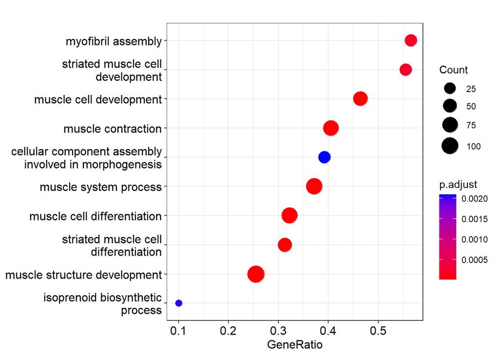

```r
dotplot(object = GOBP_GSEA)
```

GSEA解析では上位遺伝子だけでなく、下位にランクされた遺伝子の機能も調べることができます。しかし、`dotplot`ではその情報は表現できていません。

### ridgeplot

`ridgeplot`は有意なpathwayに登録されている遺伝子の発現ランキング上の分布を可視化することができます。

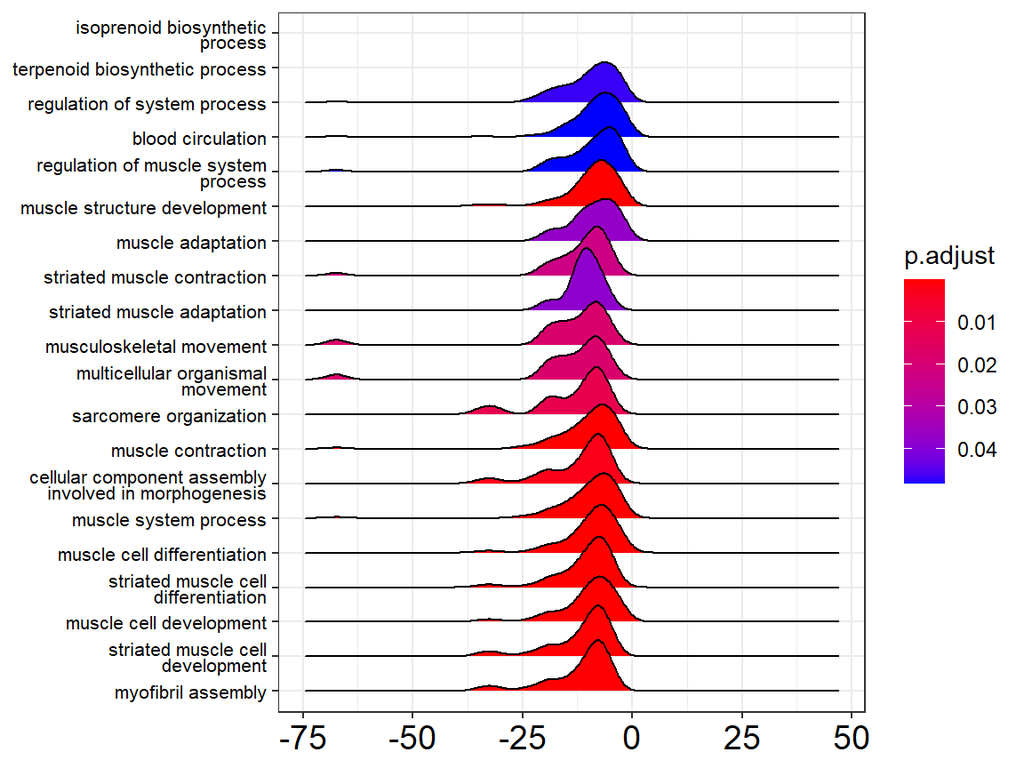

```r
# install.packages("ggridges")

ridgeplot(GOBP_GSEA) +
    theme(axis.text.y = element_text(size = 8, lineheight = 0.7))
```

ridgeplotを見ると、マイナス側に山が偏っており、発現ランク下位の遺伝子にヒットしたpathwayであったことが分かります。

### gseaplot

`gseaplot2`ではGSEA解析でおなじみのplotを描くことができます。

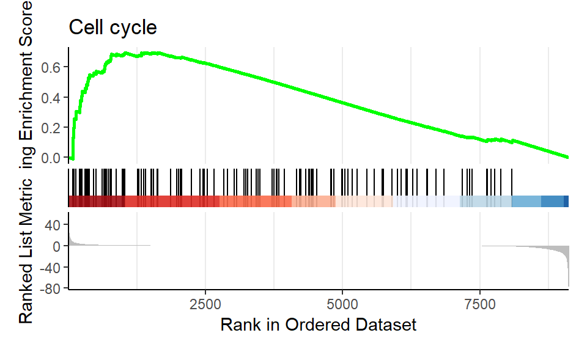

```r
gseaplot2(x = kegg_GSEA,
          geneSetID = 1, # GSEA結果の何番目のpathwayを表示するか
          title = kegg_GSEA$Description[1] # plotタイトルに表示するpathway名
          )
```

KEGGのCell cycle pathwayに登録されている遺伝子が遺伝子ランキング上位に位置していることがわかります。

複数のpathwayを同時に表示することもできます。

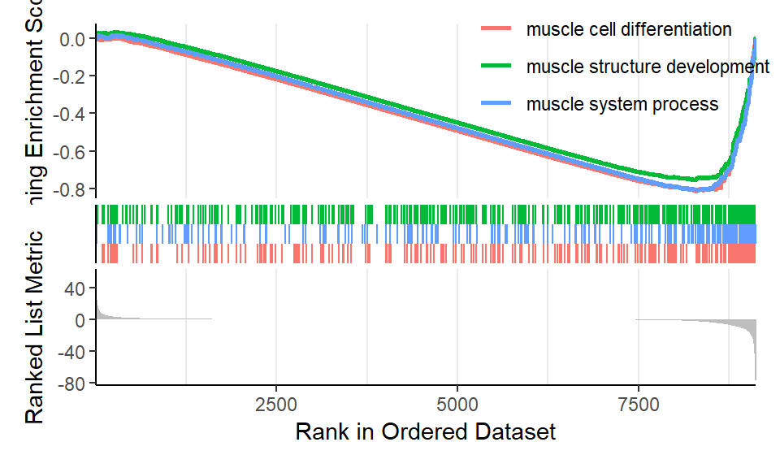

```r
gseaplot2(GOBP_GSEA,
          geneSetID = 1:3)
```

GOBPのpathwayは発現下位に位置していることがわかります。

2つのメジャーなenrichment解析アプローチを紹介しましたが、どちらが良いとかどちらで無いといけないとかはありません。自身の研究の次のステップのために有益な情報が得られたものを採用すればよいです。